# Prova - Séries Temporais

.

# Séries Temporais

#### Kaíque Ferreira Ferreira Henrique de Souza

#### **Prova de Séries Temporais**

##### 27 de Agosto de 2020

.

# Análise Descritiva

## Gráfico da Série

Nesse gráfico abaixo conseguimos ver de forma gráfica o conjunto de dados referente ao número de manchas solares de Wolfer nas seguintes variáveis:

- Número de manchas solares total anual
- Data: De 1749 a 1924

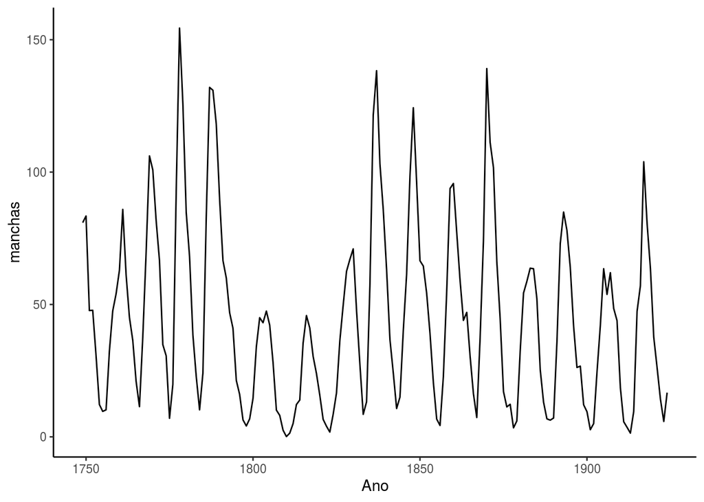

## Subsérie Manchas

O trecho abaixo foi retirado do seguinte [artigo](https://www.scielo.br/scielo.php?pid=S1806-11172003000200004&script=sci_arttext) no site SciELO.

*“As características mais claras da variabilidade solar são as mudanças com o tempo no número de manchas solares vistas na metade visível do Sol (Stuiver e Quay, 1980). Os registros observados do número de manchas solares mostram um ciclo regular médio da atividade solar próximo dos 11 anos. Não existe ainda uma explicação física completa para a observação do ciclo solar (Eddy, 1976). Modernas teorias atribuem as características periódicas das manchas solares à existência de um dínamo solar em que a convecção e a rotação diferencial da superfície interagem para amplificar e manter um assumido campo magnético inicial (Leighton, 1969). Modelos de dínamo são bem sucedidos na reprodução de certas características do ciclo de 11 anos, mas ainda não é possível explicar a variação de amplitude nas épocas de máximo e de outras mudanças características de longo período (Eddy, 1976).”*

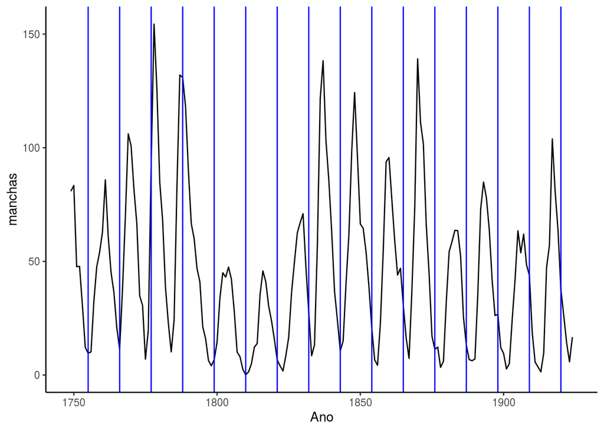

```r
ggplot(Dados_MS, aes(x = Ano, y = manchas)) + geom_path() +
  geom_vline(xintercept = c(seq(1755,1925,11)), colour = "blue")
```

Serão considerados os anos de 1755 até 1923, realizando a previsão utilizando os últimos 10 anos

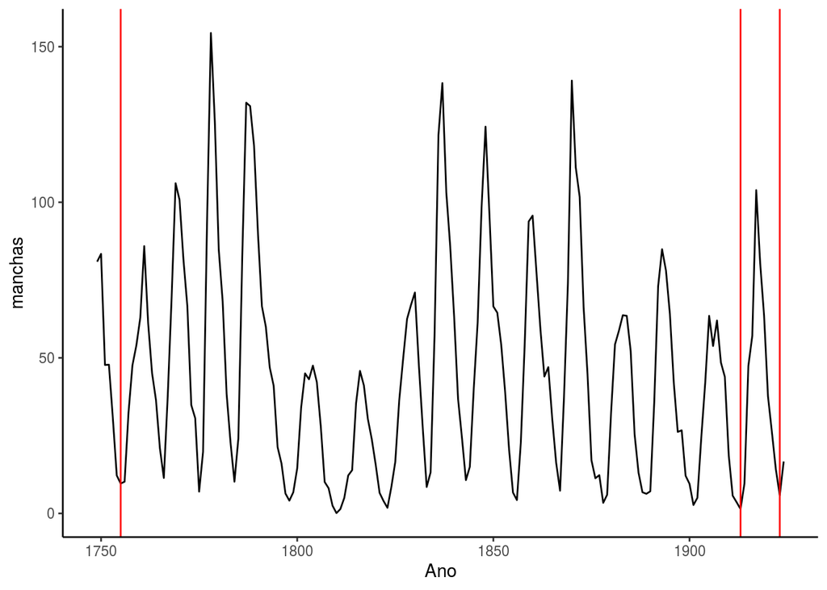

## Autocorrelação

Abaixo podemos avaliar o gráfico de autocorrelação da série original

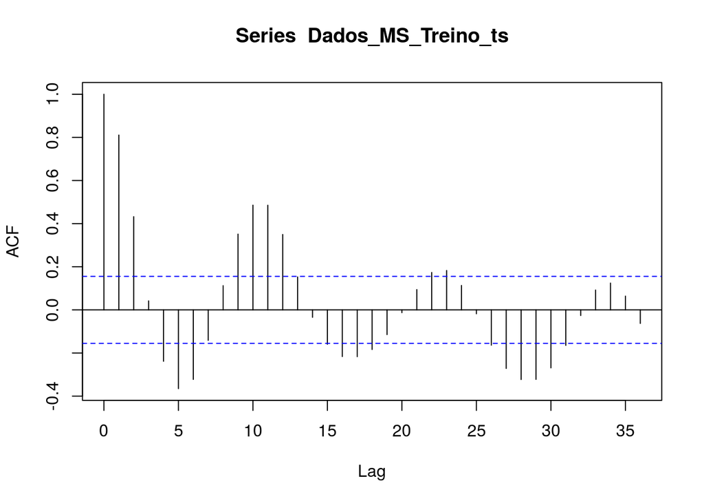

```
##
## Autocorrelations of series 'Dados_MS_Treino_ts', by lag
##
##      0      1      2      3      4      5      6      7      8      9     10
##  1.000  0.811  0.432  0.042 -0.238 -0.365 -0.322 -0.141  0.112  0.351  0.486
##     11     12     13     14     15     16     17     18     19     20     21
##  0.485  0.350  0.153 -0.035 -0.159 -0.217 -0.217 -0.184 -0.115 -0.013  0.094
##     22     23     24     25     26     27     28     29     30     31     32
##  0.173  0.183  0.113 -0.018 -0.164 -0.272 -0.323 -0.322 -0.269 -0.164 -0.026
##     33     34     35     36
##  0.092  0.124  0.064 -0.063
```

## Autocorrelação Parcial

Abaixo podemos avaliar o gráfico de autocorrelação parcial da série original

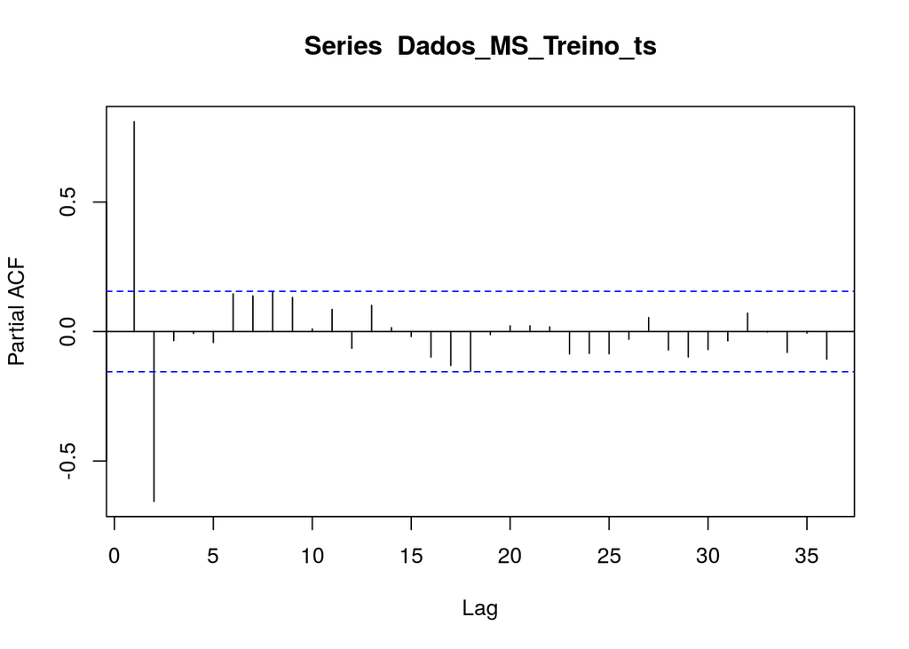

```
##
## Partial autocorrelations of series 'Dados_MS_Treino_ts', by lag
##
##      1      2      3      4      5      6      7      8      9     10     11
##  0.811 -0.656 -0.035 -0.007 -0.042  0.145  0.137  0.152  0.131  0.010  0.085
##     12     13     14     15     16     17     18     19     20     21     22
## -0.065  0.101  0.015 -0.019 -0.099 -0.131 -0.154 -0.012  0.022  0.022  0.018
##     23     24     25     26     27     28     29     30     31     32     33
## -0.087 -0.085 -0.086 -0.030  0.054 -0.072 -0.098 -0.070 -0.036  0.071 -0.002
##     34     35     36
## -0.081 -0.006 -0.107
```

## Box-Cox

Abaixo vemos o gráfico dos dados de manchas solares antes e após a transformação Box-Cox

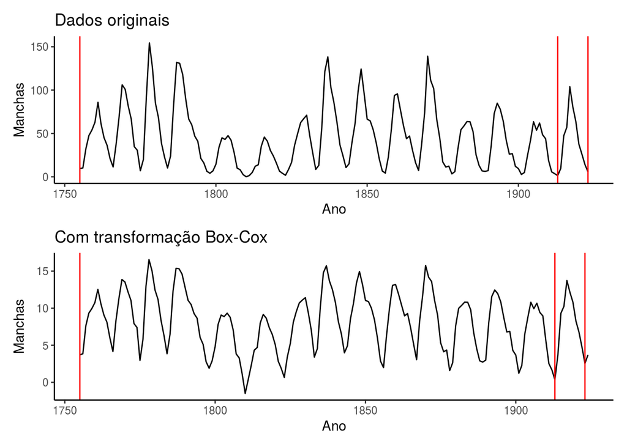

## Diferenciação

Para tentar melhorar os resultados ao aplicar um modelo de séries temporais vamos diferenciar a série de manchas e avaliar novamente as autocorrelações

### Autocorrelação

Podemos análisar a autocorrelação da série após uma diferenciação $(1 - B^{12})Z_t$

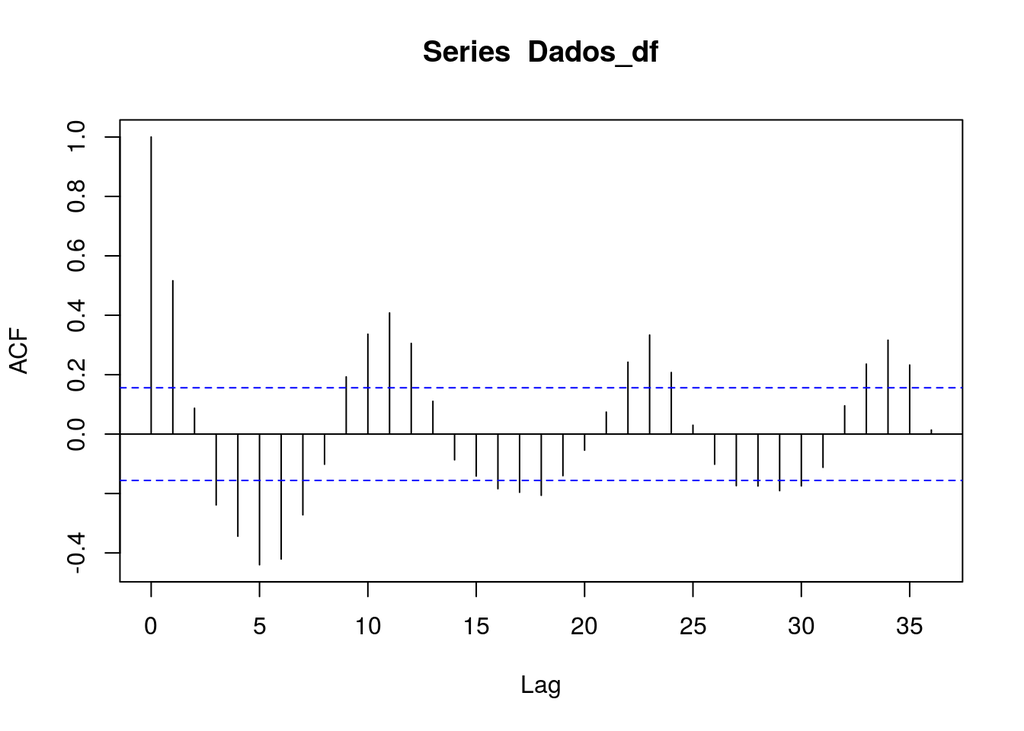

```
##
## Autocorrelations of series 'Dados_df', by lag
##
##      0      1      2      3      4      5      6      7      8      9     10
##  1.000  0.516  0.087 -0.238 -0.344 -0.440 -0.421 -0.272 -0.102  0.193  0.336
##     11     12     13     14     15     16     17     18     19     20     21
##  0.408  0.305  0.110 -0.087 -0.141 -0.184 -0.196 -0.206 -0.140 -0.054  0.074
##     22     23     24     25     26     27     28     29     30     31     32
##  0.242  0.333  0.207  0.030 -0.102 -0.174 -0.175 -0.190 -0.174 -0.112  0.095
##     33     34     35     36
##  0.236  0.316  0.232  0.014
```

### Autocorrelação Parcial

Podemos analisar a autocorrelação parcial da série após uma diferenciação $(1 - B^{12})Z_t$

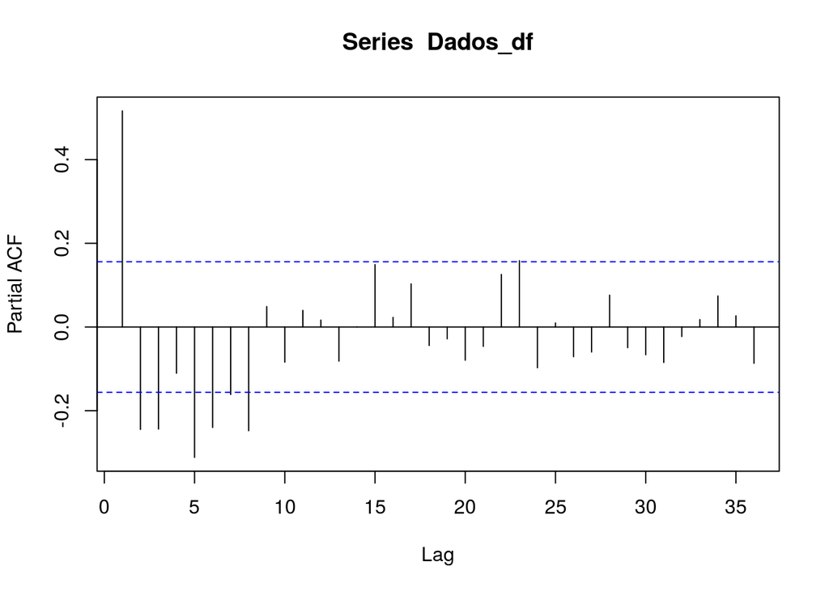

```
##
## Partial autocorrelations of series 'Dados_df', by lag
##
##      1      2      3      4      5      6      7      8      9     10     11
##  0.516 -0.245 -0.244 -0.110 -0.311 -0.240 -0.161 -0.248  0.049 -0.084  0.040
##     12     13     14     15     16     17     18     19     20     21     22
##  0.017 -0.082  0.000  0.149  0.023  0.103 -0.044 -0.028 -0.079 -0.046  0.126
##     23     24     25     26     27     28     29     30     31     32     33
##  0.158 -0.097  0.010 -0.071 -0.060  0.076 -0.049 -0.066 -0.085 -0.023  0.018
##     34     35     36
##  0.074  0.027 -0.087
```

### Autocorrelações

Abaixo podemos comparar os resultados entre as autocorrelações

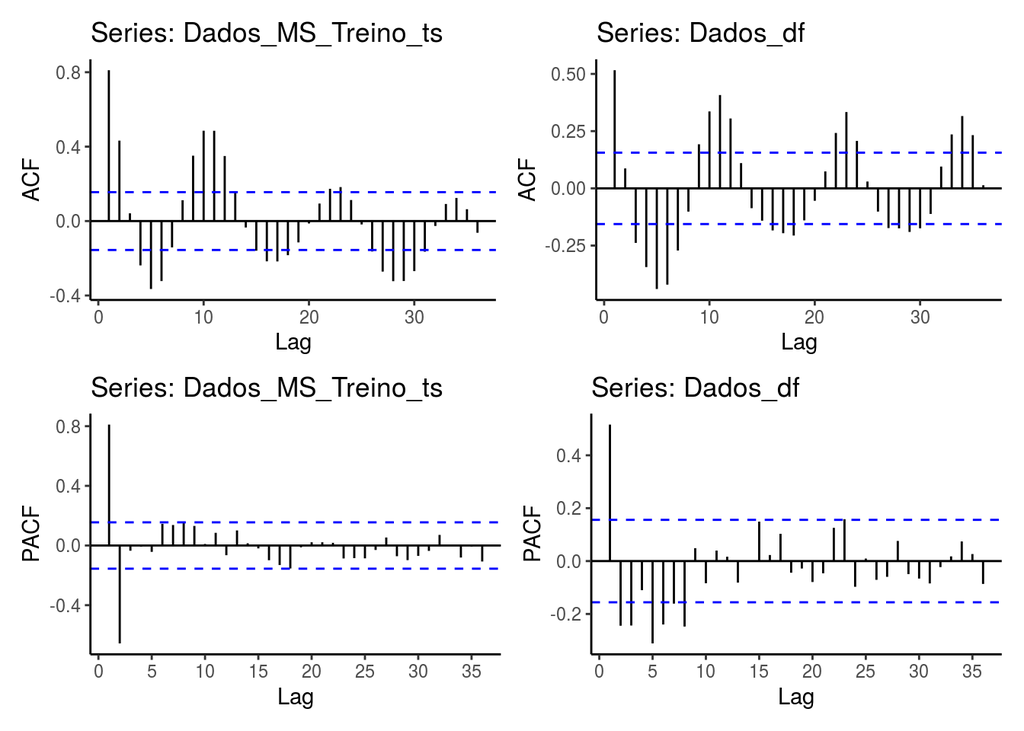

# Auto-arima

Vamos utilizar a função *auto.arima* para encontrar um primeiro modelo sugerido e assim fazer os testes de diagnósticos para avaliar seu ajuste em relação à série dos dados

```
## Series: Dados_MS_Treino_BC_ts
## ARIMA(3,1,1)
##
## Coefficients:
##          ar1      ar2      ar3      ma1
##       1.2480  -0.4896  -0.1393  -0.8975
## s.e.  0.0888   0.1272   0.0861   0.0468
##
## sigma^2 estimated as 2.902:  log likelihood=-307.34
## AIC=624.67   AICc=625.07   BIC=639.99
##
## Training set error measures:
##                       ME     RMSE      MAE       MPE     MAPE      MASE
## Training set -0.02449959 1.676657 1.272346 -10.91756 32.46464 0.6637039
##                     ACF1
## Training set -0.01262203
```

Percebemos que esse é o modelo indicado pelo *auto.arima*

$$(1-\phi_1B^1-\phi_2B^2-\phi_3B^3)(1-B)^{1}Z_t^{*}=(1-\theta_1B^1)a_t$$

## Diagnostico

Vamos realizar testes de diagnósticos para avaliar o modelo sugerido pelo *auto.arima* através dos gráficos de autocorrelação e de autocorrelação parcial e também com o teste Ljung-Box

### Autocorrelação

Podemos analisar a autocorrelação da série para o modelo sugerido pelo *auto.arima*

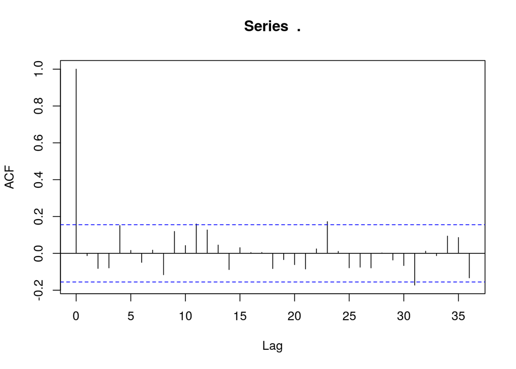

### Autocorrelação Parcial

Podemos analisar a autocorrelação parcial da série para o modelo sugerido pelo *auto.arima*

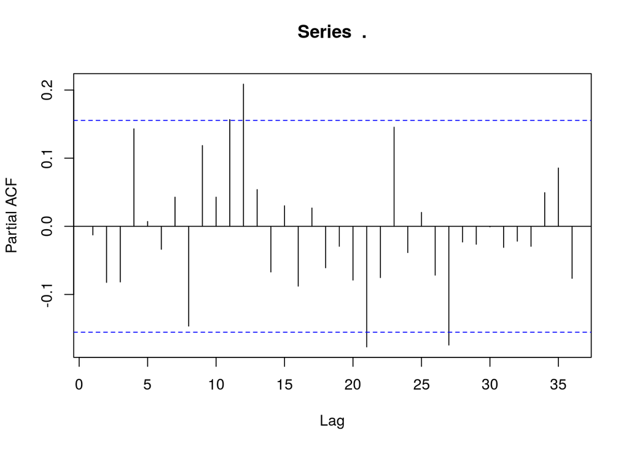

### Teste Ljung-Box

```
##
##  Ljung-Box test
##
## data:  Residuals from ARIMA(3,1,1)
## Q* = 29.707, df = 20, p-value = 0.07475
##
## Model df: 4.   Total lags used: 24
```

```
##
##  Ljung-Box test
##
## data:  Residuals from ARIMA(3,1,1)
## Q* = 34.31, df = 26, p-value = 0.1274
##
## Model df: 4.   Total lags used: 30
```

```
##
##  Ljung-Box test
##
## data:  Residuals from ARIMA(3,1,1)
## Q* = 43.625, df = 31, p-value = 0.06572
##
## Model df: 4.   Total lags used: 35
```

## Medidas de Acurácia

```
##                       ME     RMSE      MAE       MPE     MAPE      MASE
## Training set -0.02449959 1.676657 1.272346 -10.91756 32.46464 0.6637039
## Test set      2.18433647 3.253809 2.723970  16.93628 36.28615 1.4209256
##                     ACF1
## Training set -0.01262203
## Test set              NA
```

### EQM

Com o modelo apresentado obtemos um EQM de:

```r
accuracy[2,"RMSE"]^2
```

```
## [1] 10.58727
```

# Modelo 2

Depois de varias tentativa de encontrar um melhor modelo para prever os últimos 10 anos com um MAPE sendo o menor possível encontrei um ARMA(6,5) para os dados com transformação Box-Cox

$$(1-\phi_1B^1-\phi_2B^2-\phi_3B^3-\phi_4B^4-\phi_5B^5-\phi_6B^6)Z_t^{*}=(1-\theta_1B^1-\theta_2B^2-\theta_3B^3-\theta_4B^4-\theta_5B^5)a_t$$

## Diagnostico Modelo 2

Vamos realizar testes de diagnósticos para avaliar o modelo ARMA(6,5) através dos gráficos de autocorrelação e de autocorrelação parcial e também com o teste Ljung-Box

### Autocorrelação

Podemos analisar a autocorrelação da série para o modelo ARMA(6,5)

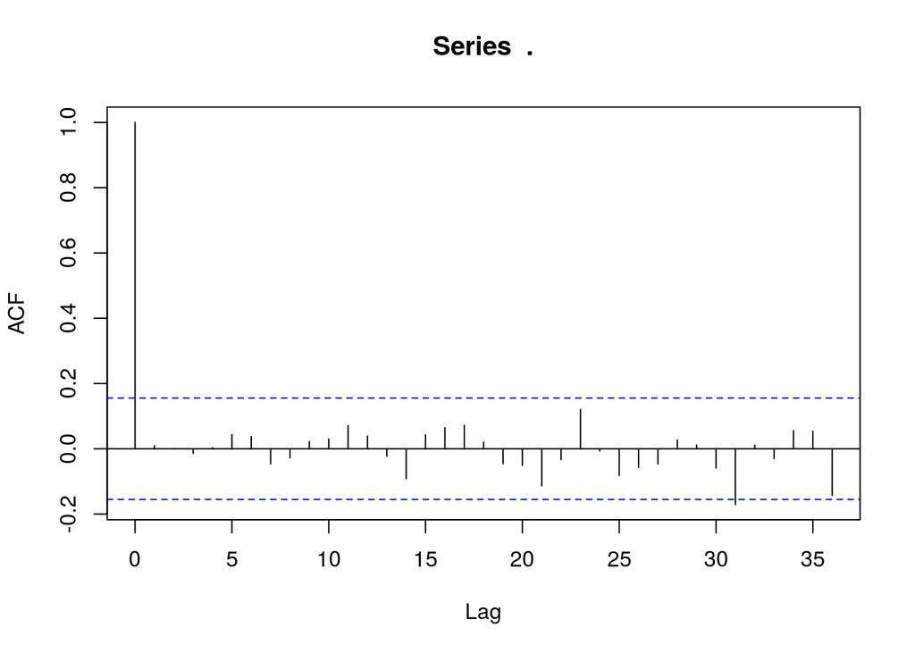

### Autocorrelação Parcial

Podemos analisar a autocorrelação parcial da série para o modelo ARMA(6,5)

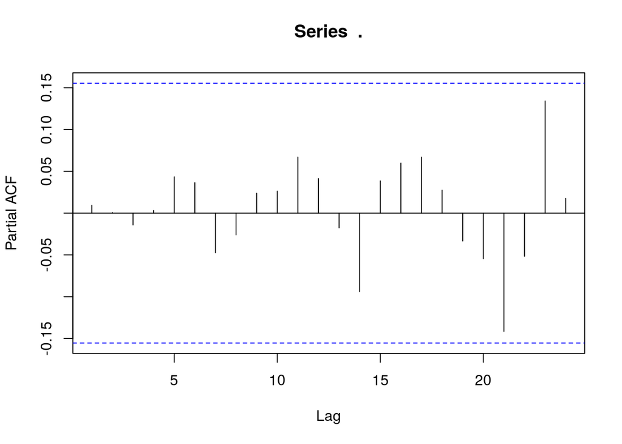

### Teste Ljung-Box

```
##
##  Ljung-Box test
##
## data:  Residuals from ARIMA(6,0,5) with non-zero mean
## Q* = 12.313, df = 12, p-value = 0.4209
##
## Model df: 12.   Total lags used: 24
```

```
##
##  Ljung-Box test
##
## data:  Residuals from ARIMA(6,0,5) with non-zero mean
## Q* = 15.483, df = 18, p-value = 0.6285
##
## Model df: 12.   Total lags used: 30
```

```
##
##  Ljung-Box test
##
## data:  Residuals from ARIMA(6,0,5) with non-zero mean
## Q* = 27.002, df = 24, p-value = 0.3044
##
## Model df: 12.   Total lags used: 36
```

## Previsão

Vamos fazer a previsão dos dados da série de manchas solares para os últimos 10 anos

### Observado e Preditos

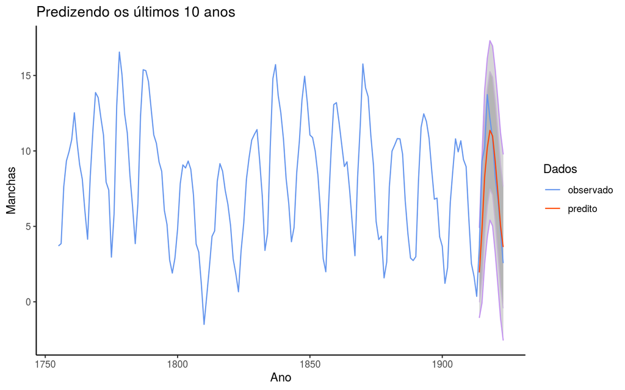

```r
horizonte = 10
reps <- rep(NA, length(Dados_MS_Treino_BC_ts))

df_pred <- tibble(observado = Dados_MS_Treino_BC_ts,
                  predito = reps,
                  lo_80 = reps,
                  hi_80 = reps,
                  lo_95 = reps,
                  hi_95 = reps) %>%
  bind_rows(
    forecast(mod2, h = horizonte) %>%
      as_tibble() %>%
      mutate(observado = Dados_MS_BC_Teste) %>%
      rename(predito = `Point Forecast`, lo_80 = `Lo 80`, hi_80 = `Hi 80`, lo_95 = `Lo 95`, hi_95 = `Hi 95`) %>%
      select(observado, predito, everything())
  ) %>%
  mutate(data = Dados_MS$Ano)


df_pred %>%
  pivot_longer(c(observado, predito)) %>%
  ggplot(aes(x = data, y = value, color = name)) +
  geom_ribbon(aes(ymin = lo_80, ymax = hi_80), color = '#e8d5f9', alpha = 0.2) +
  geom_ribbon(aes(ymin = lo_95, ymax = hi_95), color = '#c495f0', alpha = 0.2) +
  geom_line() +
  scale_color_manual('Dados', values = c('#6495ED', '#FF4500')) +
  labs(x = 'Ano', y = 'Manchas', title = 'Predizendo os últimos 10 anos')
```

### Medidas de Acurácia

```
##                       ME     RMSE      MAE        MPE     MAPE      MASE
## Training set 0.003951024 1.522328 1.143823 -10.922518 28.53040 0.5966614
## Test set     0.953828688 2.077769 1.561428   7.879152 21.63744 0.8144998
##                     ACF1
## Training set 0.009325453
## Test set              NA
```

#### EQM

Com o último modelo apresentado obtemos um EQM de:

```r
accuracy[2,"RMSE"]^2
```

```
## [1] 4.317125
```